# DATA 505: Homework #2

Author

Kendall Leonard

**Abstract:**

This is a technical blog post of **both** an HTML file *and* .qmd file hosted on GitHub pages.

# Setup

3. Get your [GitHub Pages](https://docs.github.com/en/pages/quickstart) ready.

**Step Up Code:**

```r
library(tidyverse)
library(caret)
library(fastDummies)
wine <- readRDS(gzcon(url("https://github.com/cd-public/D505/raw/master/dat/wine.rds")))
```

**Explanation:**

> **TODO**:

> 1) Importing the Tidyverse library, which is used throughout this post to format, filter, and otherwise manipulate the data into forms necessary to complete the assignment

> 2) Importing the caret library, which is used for the regression models we will create later.

> 3) Importing the fastDummies library, which assists in creating dummy variables from columns that contained categorical variables.

> 4) Then I am reading in the `wine.rds` data from Calvin’s github and saving it as ‘wine’.

# Feature Engineering

We begin by engineering an number of features.

1. Create a total of 10 features (including points).
2. Remove all rows with a missing value.
3. Ensure only log(price) and engineering features are the only columns that remain in the `wino` dataframe.

```r
wino <- wine %>%
  mutate(fr = (country == "France")) %>% #1
  mutate(cab = str_detect(variety, "Cabernet")) %>% #2
  mutate(lprice = log(price)) %>% #3
  mutate(lpoints = log(points))%>% #4
  mutate(wine_age = 2025 - year)%>% #5
  mutate(wine_country = as.factor(country))%>% #6
  mutate(wine_variety = as.factor(variety))%>% #7
  mutate(region_interaction = paste(region_1, region_2, sep = "_"))%>% #8
#  mutate(price_per_point = price / points)%>% #9
  mutate(points_scaled = (points - min(points)) / (max(points) - min(points)))%>%
  mutate(taster_reviews_count = as.numeric(table(taster_name)[taster_name]))%>%
  drop_na(fr, cab) %>%
  select(lprice, points, fr, cab, lpoints, wine_age, wine_country, wine_variety, points_scaled, taster_reviews_count)
```

# Caret

We now use a train/test split to evaluate the features.

1. Use the Caret library to partition the wino dataframe into an 80/20 split.

```r
wine_index <- createDataPartition(wino$lprice, p = 0.8, list = FALSE)
wino_tr <- wino[wine_index, ]
wino_te <- wino[-wine_index, ]
```

2. Run a linear regression with bootstrap resampling.

```r
m1 <- train(lprice ~ .,
  data = wino_tr,
  method = "lm",
  trControl = trainControl(method = "boot", number = 5, repeats = 3)
)
m1
```

```
Linear Regression

71603 samples
    9 predictor

No pre-processing
Resampling: Bootstrapped (5 reps)
Summary of sample sizes: 71603, 71603, 71603, 71603, 71603
Resampling results:

  RMSE       Rsquared   MAE
  0.4500333  0.5284388  0.3480533

Tuning parameter 'intercept' was held constant at a value of TRUE
```

3. Report RMSE on the test partition of the data.

```r
predictions <- predict(m1, newdata = wino_te)
rmse <- sqrt(mean((predictions - wino_te$lprice)^2))
print(paste("RMSE on the test partition:", round(rmse, 4)))
```

```
[1] "RMSE on the test partition: 0.4503"
```

# Variable selection

We now graph the importance of your 10 features.

[figure not shown]

```r
plot(varImp(m1, scale = TRUE))
```

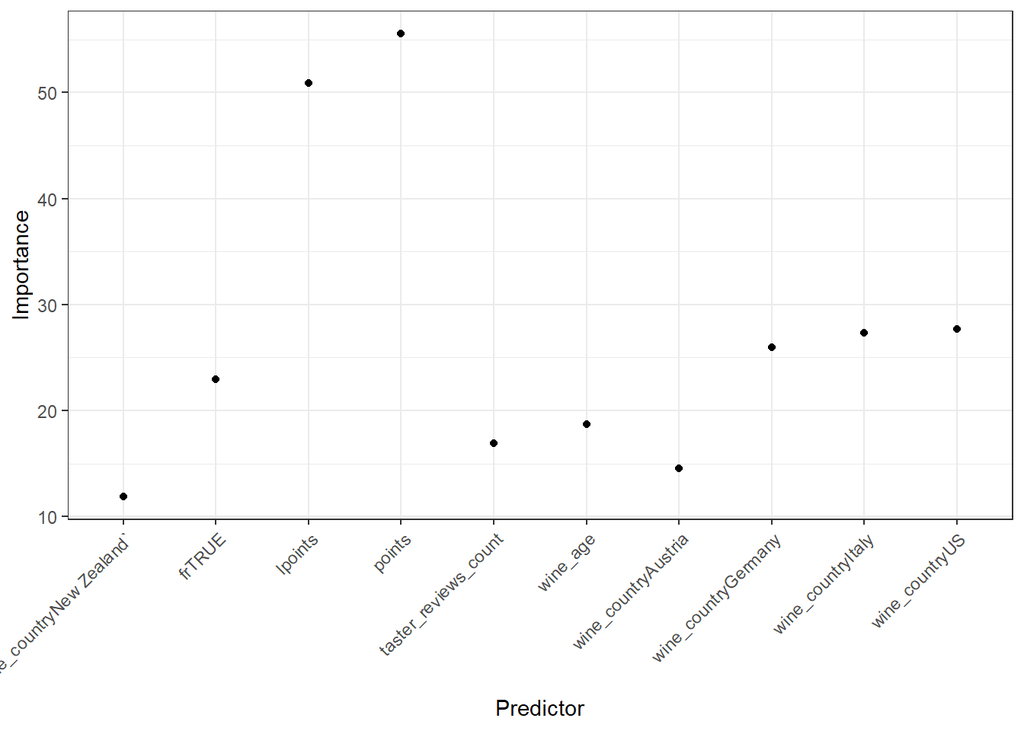

```r
importance <- varImp(m1, scale = FALSE)


importance_df <- data.frame(Predictor = rownames(importance$importance),
                            Importance = importance$importance$Overall)

importance_df%>%
  top_n(10)%>%
  ggplot(aes(x=Predictor, y=Importance))+
  geom_point()+
  theme_bw()+
  theme(axis.text.x = element_text(angle = 45, hjust = 1))
```